# Boston_crime_map

Pierre Mulliez

03/06/2021

## Boston crime map using leaflet

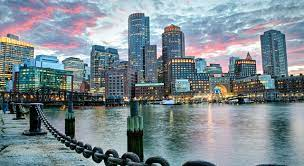

**source**: Kaggle  
**Link**: https://www.kaggle.com/AnalyzeBoston/crimes-in-boston?select=crime.csv

## Obective

- Understand the crime rate in Boston by District
- Drill down by day of the week; week end versus weekday
- Zoom in on a district observing what type of crime is committed

## Small EDA

```
##   INCIDENT_NUMBER OFFENSE_CODE              OFFENSE_CODE_GROUP
## 1      I182070945          619                         Larceny
## 2      I182070943         1402                       Vandalism
## 3      I182070941         3410                           Towed
## 4      I182070940         3114            Investigate Property
## 5      I182070938         3114            Investigate Property
## 6      I182070936         3820 Motor Vehicle Accident Response
##                          OFFENSE_DESCRIPTION DISTRICT REPORTING_AREA SHOOTING
## 1                         LARCENY ALL OTHERS      D14            808
## 2                                  VANDALISM      C11            347
## 3                        TOWED MOTOR VEHICLE       D4            151
## 4                       INVESTIGATE PROPERTY       D4            272
## 5                       INVESTIGATE PROPERTY       B3            421
## 6 M/V ACCIDENT INVOLVING PEDESTRIAN - INJURY      C11            398
##      OCCURRED_ON_DATE YEAR MONTH DAY_OF_WEEK HOUR   UCR_PART      STREET
## 1 2018-09-02 13:00:00 2018     9      Sunday   13   Part One  LINCOLN ST
## 2 2018-08-21 00:00:00 2018     8     Tuesday    0   Part Two    HECLA ST
## 3 2018-09-03 19:27:00 2018     9      Monday   19 Part Three CAZENOVE ST
## 4 2018-09-03 21:16:00 2018     9      Monday   21 Part Three  NEWCOMB ST
## 5 2018-09-03 21:05:00 2018     9      Monday   21 Part Three    DELHI ST
## 6 2018-09-03 21:09:00 2018     9      Monday   21 Part Three  TALBOT AVE
##        Lat      Long                    Location
## 1 42.35779 -71.13937 (42.35779134, -71.13937053)
## 2 42.30682 -71.06030 (42.30682138, -71.06030035)
## 3 42.34659 -71.07243 (42.34658879, -71.07242943)
## 4 42.33418 -71.07866 (42.33418175, -71.07866441)
## 5 42.27537 -71.09036 (42.27536542, -71.09036101)
## 6 42.29020 -71.07159 (42.29019621, -71.07159012)
```

```
## [1] "number of collumns 17"
```

```
## [1] "number of rows 319073"
```

Note that the siz of the dataset, we will subset it to avoid long loading time.

```r
#lets select only 2018 data, avoid loading time of the dataset
paste("what years are in the dataset? ", toString(unique(year(bostondata$OCCURRED_ON_DATE))))
```

```
## [1] "what years are in the dataset?  2018, 2017, 2016, 2015"
```

```r
paste("The dataset size has", as.character(unlist(count(bostondata[year(bostondata$OCCURRED_ON_DATE) == "2018",]))), "rows")
```

```
## [1] "The dataset size has 65685 rows"
```

```r
#still quite big, lets get only June
subboston <- bostondata %>% filter(year(bostondata$OCCURRED_ON_DATE) == "2018" & month(bostondata$OCCURRED_ON_DATE) == "6",)
#given the size of the dataset lets select only monday and sunday
subbostonMondays <- subboston  %>% filter(DAY_OF_WEEK == "Monday" | DAY_OF_WEEK == "Sunday")
```

## Build the first map

[interactive chart not shown]

We can notice that we have outlier(s) point(s)

```r
#we can notice some Outliers lets remove them using UDF
removeoutliers <- function(col,df){
  listquantiles <-  quantile(col, probs = c(0.99,0.01), na.rm = TRUE)
  newdf <- subset(df, col > listquantiles[2] & col < listquantiles[1])
  return(newdf)
}
cleanBoston <- removeoutliers(subbostonMondays$Lat,subbostonMondays)
```

## Map by district

### Preparation

- Tag the shooting using the size of the pin
- Color code the district
- add a control panel to visualize the desired district

```r
#tag the shooting as bigger point
cleanBoston$size <- 20
cleanBoston[cleanBoston$SHOOTING == "Y",]$size <- 80
#tag the district with different colors
dist <- unique(cleanBoston[cleanBoston$DISTRICT != "",]$DISTRICT)
color <- c("green","blue","orange","purple","red","coral","black", "brown","chocolate","grey", "orchid","yellow")
colordf <- data.frame(DISTRICT = dist, col = color)
#merge the color dataframe to our boston df
t <- merge(cleanBoston, colordf, by.x = "DISTRICT", by.y = "DISTRICT")
```

### Build the map

- Text appearing on click corresponding to the offense type

```r
# Plot leaflet map
bos_m <- leaflet(t) %>% addTiles()

#We will have the popup text to equal the offence

bos_map <- addCircles(bos_m, lng = ~Long, lat = ~Lat, popup = ~OFFENSE_CODE_GROUP, color = ~col, radius = ~size,fill = TRUE,group = ~DISTRICT )
bos_map <- addLegend(bos_map,"bottomright",
                      labels = colordf$DISTRICT,
                     colors = colordf$col,
                     title = "Disticts",
                     opacity = 1,
                     group = "Legend")
bos_map <- addLayersControl(bos_map, position = "bottomleft", overlayGroups = c("Legend",unique(t$DISTRICT)) , options = layersControlOptions(collapsed = FALSE))

bos_map
```

[interactive chart not shown]

Note: West Roxbery - B2 seems like a safe neighboorod

## Map by day

### Preparation

- Calculate the probability of offense given all the offenses in the dataset
- Color code the days
- Enlarge rare events

```r
#color of the day of the week
t$mcol <- "red"
t[t$DAY_OF_WEEK == "Sunday",]$mcol <- "blue"

#We will analyse more deeply what the proportion of offenses are and add them as popup
t$prop <- paste("offence", toString(0),"%")
t$propint <- 0
unique(t$OFFENSE_CODE_GROUP)
```

```
##  [1] "Motor Vehicle Accident Response"  "Investigate Property"
##  [3] "Property Lost"                    "Vandalism"
##  [5] "Fraud"                            "Larceny"
##  [7] "License Violation"                "Warrant Arrests"
##  [9] "Auto Theft"                       "Simple Assault"
## [11] "Harassment"                       "Investigate Person"
## [13] "Medical Assistance"               "Other"
## [15] "Larceny From Motor Vehicle"       "Robbery"
## [17] "Property Found"                   "Towed"
## [19] "Recovered Stolen Property"        "Drug Violation"
## [21] "Assembly or Gathering Violations" "Disorderly Conduct"
## [23] "Aggravated Assault"               "Missing Person Reported"
## [25] "Verbal Disputes"                  "Firearm Violations"
## [27] "Commercial Burglary"              "Property Related Damage"
## [29] "Confidence Games"                 "Search Warrants"
## [31] "Fire Related Reports"             "Residential Burglary"
## [33] "Violations"                       "Restraining Order Violations"
## [35] "Operating Under the Influence"    "HOME INVASION"
## [37] "Ballistics"                       "Police Service Incidents"
## [39] "Arson"                            "Liquor Violation"
## [41] "Missing Person Located"           "Auto Theft Recovery"
## [43] "Other Burglary"                   "Landlord/Tenant Disputes"
## [45] "Counterfeiting"                   "Firearm Discovery"
## [47] "Offenses Against Child / Family"  "Service"
## [49] "Evading Fare"                     "Bomb Hoax"
## [51] "License Plate Related Incidents"  "Prostitution"
## [53] "Phone Call Complaints"            "Criminal Harassment"
```

```r
t <- na.omit(t)
for (var in unique(t$OFFENSE_CODE_GROUP)){
  perc <- round(count(t[t$OFFENSE_CODE_GROUP == var,])/nrow(t),digits = 2)
  t[t$OFFENSE_CODE_GROUP == var,]$prop <- paste(var, toString(perc), "%")
  t[t$OFFENSE_CODE_GROUP == var,]$propint <- toString(perc)
}

#We will enlarge the very rare events
t$evsize <- 20
t[t$propint < 0.05,]$evsize <- 40
t[t$propint < 0.02,]$evsize <- 60
```

### Build the map

- reset the view for better visibility

[interactive chart not shown]

Note: Apart for Brighton crime that seemed higher on mondays the map does not point toward a notable difference in the rate of crime between sundays and mondays

## Apply the map to a single district

- District B12
- Highlighting Dudley street

[interactive chart not shown]

  Note: a lot of rare event happening in this part of the city, particularly in Dudley street